```python
!pip install pyreadr
!pip install rpy2
```

```python
import pandas as pd
import pyreadr
from rpy2.robjects import r, pandas2ri
```

# **Analysis of Election Trends Based on Demographic, Economic, and Educational Data**

# Josh Belew and Catherine Brooks

# [Our github.io](https://cathbrooks.github.io/)

# **Project Goals**

Some inital Hypotheses:

- A lot more counties will vote republican
- There will be relatively high correlations between race and party
- Counties with higher education will vote democrat

# **Collaboration Plan**

We have a set time to meet every Thursday at 1:00p to discuss the work we did that week and what needs to be done the next week, along with any coding we can get done together. We will meet over zoom an additional time every other week to collaborate on code and analysis. We have a shared google drive folder that keeps everything organized and accessible for both of us, along with a private repository branch so we can easily share code.

# **Data Transformation**

## Table 1: Election Results

For the presidential election results we will be using a data set from Harvard Dataverse containing the presidential election results per county from 1868-2020. The dataset can be found here: https://dataverse.harvard.edu/dataset.xhtml?persistentId=doi:10.7910/DVN/DGUMFI

```python
#reset to /content root folder and run these in order
%cd /content/
!git clone https://github.com/cathbrooks/cathbrooks.github.io.git
%cd /content/cathbrooks.github.io/data
!ls
```

```python
# Activate automatic conversion
pandas2ri.activate()

#load in Rdata file
r['load']('dataverse_shareable_presidential_county_returns_1868_2020.Rdata')

#get dataframe from file
pres_elections_release_r = r['pres_elections_release']
pres_elections_release_df = pd.DataFrame(pres_elections_release_r)
pres_elections_release_df
```

```python
# Select the necessary columns
selected_cols = ['election_year','fips','county_name','state','sfips','democratic_raw_votes','republican_raw_votes','raw_county_vote_totals']
pres_elections_release_df = pres_elections_release_df[selected_cols].copy()

# Create new columns for the percenatage democratic and republican vote
pres_elections_release_df['percent_democrat'] = pres_elections_release_df['democratic_raw_votes'] / pres_elections_release_df['raw_county_vote_totals']
pres_elections_release_df['percent_republican'] = pres_elections_release_df['republican_raw_votes'] / pres_elections_release_df['raw_county_vote_totals']

# Set the election_year column to an int64 data type
pres_elections_release_df['election_year'] = pres_elections_release_df['election_year'].astype('int64')

#filter for election years 1988, 2000, 2012, 2020
pres_election_filtered_df = pres_elections_release_df[pres_elections_release_df['election_year'].isin([1988,2000,2012,2020])].copy()
pres_election_filtered_df.rename(columns={'fips': 'FIPS_code', 'election_year': 'Year'}, inplace=True)
pres_election_filtered_df.drop(columns=['sfips'], inplace=True)

pres_elections_release_df
```

## Table 2: Education

A data set with county level eduaction attainment percentage for their adult population. These categories will be used as our education factors in our model. The data set can be found here: https://www.ers.usda.gov/data-products/county-level-data-sets/county-level-data-sets-download-data/

```python
# pivot the df according to tidy data standards

df_education = pd.read_csv("EducationData.csv")

years = [1990, 2000, 2008, 2017]
df_education_new = pd.DataFrame()

for year in years:

  col_names = ["Federal Information Processing Standard (FIPS) Code",	"State"	, "Area name"]
  col_new = ["Federal Information Processing Standard (FIPS) Code",	"State"	, "Area name"]

  for col in df_education.columns:
    if str(year) in col:
      col_names.append(col)
      col_new.append(col.split(',')[0])

  df_temp = df_education[col_names].set_axis(col_new, axis=1)
  df_temp['Year'] = year

  df_education_new = pd.concat([df_education_new, df_temp])

#fill fips code
df_education_new = df_education_new.rename(columns={'Federal Information Processing Standard (FIPS) Code': 'FIPS_code'})
df_education_new['FIPS_code'] = df_education_new['FIPS_code'].astype(str).str.zfill(5)
df_education_new.drop(columns=['Less than a high school diploma', 'High school diploma only', 'Some college or associate\'s degree', 'Bachelor\'s degree or higher'], inplace=True)

#match election years
df_education_new['Year'].replace(1990, 1988, inplace=True)
df_education_new['Year'].replace(2008, 2012, inplace=True)
df_education_new['Year'].replace(2017, 2020, inplace=True)

df_education_new
```

## Table 3: Demographics

A data set containing country level demographic data based on race, origin, sex, and age group. These categories will be the demographic factors we use in our model. The data can be found here: https://seer.cancer.gov/popdata/download.html#single

```python
df_demographics = pd.read_csv("demographic_data.csv")
df_demographics['County FIPS code'] = df_demographics['County FIPS code'].astype(str).str.zfill(3) #make the county code three digits

# Convert 'state_fips' and 'county_fips' columns to strings so we can combine them into one FIPS_code column for merging purposes
df_demographics['State FIPS code'] = df_demographics['State FIPS code'].astype(str)
df_demographics['County FIPS code'] = df_demographics['County FIPS code'].astype(str)
df_demographics['FIPS_code'] = df_demographics['State FIPS code'] + df_demographics['County FIPS code']

#drop unneeded columns
df_demographics.drop(columns=['Registry (Geographic Definition Only)', 'Unnamed: 0', 'State FIPS code', 'County FIPS code'], inplace=True)
df_demographics['FIPS_code'] = df_demographics['FIPS_code'].str.zfill(5)

# convert race, orgin, sex, and age codes to categorical values

df_demographics['Race'] = df_demographics['Race'].map({1:'White', 2:'Black', 3:"American Indian/Alaska Native", 4:"Asian or Pacific Islander"})
df_demographics["Origin"] = df_demographics["Origin"].map({0:'Non-Hispanic', 1:'Hispanic'})
df_demographics['Sex'] = df_demographics['Sex'].map({1:'Male',2:'Female'})

# conver to correct years

df_demographics['Year'].replace({1990:1988, 2000:2000, 2010:2012, 2020:2020}, inplace=True)

df_demographics
```

## Table 4: Poverty

Multiple data sets with county level poverty rates. The individual data sets can be downloaded here: https://data.ers.usda.gov/reports.aspx?ID=17826

Tidy 2021 dataframe:

```python
df_poverty_2021 = pd.read_csv("PovertyEstimates 2021.csv")
df_poverty_2021.drop(columns=['Rural-urban_Continuum_Code_2003',
                              'Urban_Influence_Code_2003',
                              'Rural-urban_Continuum_Code_2013',
                              'Urban_Influence_Code_ 2013',
                              'CI90LBALL_2021',
                              'CI90UBALL_2021',
                              'CI90LBALLP_2021',
                              'CI90UBALLP_2021',
                              'CI90LB017_2021',
                              'CI90UB017_2021',
                              'CI90LB017P_2021',
                              'CI90UB017P_2021',
                              'CI90LB517_2021',
                              'CI90UB517_2021',
                              'CI90LB517P_2021',
                              'CI90UB517P_2021',
                              'CI90LBINC_2021',
                              'CI90UBINC_2021',
                              'CI90LB04_2021',
                              'CI90UB04_2021',
                              'CI90LB04P_2021',
                              'CI90UB04P_2021',
                              'POVALL_2021',      #POVALL_2021 = Estimate of people of all ages in poverty 2021
                              'POV017_2021',
                              'PCTPOV017_2021',
                              'POV517_2021',
                              'PCTPOV517_2021',
                              'MEDHHINC_2021',
                              'POV04_2021',
                              'PCTPOV04_2021'], inplace=True)

#rename poverty_rate column for clarity
df_poverty_2021.rename(columns={'PCTPOVALL_2021': 'Poverty_rate', 'FIPS_Code': 'FIPS_code'}, inplace=True)

# Add a new column 'year'
df_poverty_2021['Year'] = 2021
```

Tidy 1989 and 1999 dataframe:

```python
df_poverty_8999 = pd.read_csv("povertyrates1989-1999.csv")

#idk what these columns were they arent in the original excel file...
#also the last two columns are missing from the csv idk why
df_poverty_8999.drop(columns=['BEALE93',
                              'FPVDET89',
                              'FINPOV89',
                              'FPOV89',
                              'FPVDET99',
                              'FINPOV99',
                              'FPOV99',
                              'Population base 1989',
                              'Population in poverty 1989',
                              'Population base 1999',
                              'Population in poverty 1999',
                              'Children <18 1989 base',
                              'Children <18 1989 in pov',
                              'Children <18 1989 pov rate',
                              'Children <18 1999 base',
                              'Children <18 1999 in pov',
                              'Children <18 1999 pov rate'], inplace=True)

#make one column for poverty_rate and create a year column
df_1989 = df_poverty_8999[['FIPS', 'STABR', 'AREA', 'Poverty rate 1989']].copy()
df_1989.rename(columns={'Poverty rate 1989': 'Poverty_rate', 'FIPS': 'FIPS_code', 'STABR': 'Stabr', 'AREA': 'Area_name'}, inplace=True)
df_1989['Year'] = 1989

# Create a new DataFrame with the 'Poverty rate 1999' data
df_1999 = df_poverty_8999[['FIPS', 'STABR', 'AREA', 'Poverty rate 1999']].copy()
df_1999.rename(columns={'Poverty rate 1999': 'Poverty_rate', 'FIPS': 'FIPS_code', 'STABR': 'Stabr', 'AREA': 'Area_name'}, inplace=True)
df_1999['Year'] = 1999

# Concatenate the two DataFrames
poverty_8999_df = pd.concat([df_1989, df_1999], ignore_index=True)
poverty_8999_df
```

Tidy 2009 dataframe:

```python
df_poverty_2009 = pd.read_csv("poverty_2009.csv")
df_poverty_2009.drop(columns=['RUC',
                              'Lower bound',
                              'Upper bound',
                              'Children en Poverty Percent',
                              'Lower bound.1',
                              'Upper bound.1'
                           ], inplace=True)
df_poverty_2009.rename(columns={'FIPS': 'FIPS_code', 'All People In Poverty Percent': 'Poverty_rate', 'Name': 'Area_name'}, inplace=True)
df_poverty_2009['Year'] = 2009

#There was one weird row with wrong values index=2948	FIPS_code=Adams County	Area_name=6	Poverty_rate=14.5	Year=2009 so I dropped it
# df_poverty_2009[~df_poverty_2009['FIPS_code'].astype(str).str.isdigit()]
df_poverty_2009 = df_poverty_2009.drop(2948)

#convert FIPS_code to ints so we can merge
df_poverty_2009['FIPS_code'] = df_poverty_2009['FIPS_code'].astype(int)

#Get Stabr column for 2009
poverty_2009_df = pd.merge(poverty_8999_df, df_poverty_2009, how='inner', on='FIPS_code', suffixes=['1989',''])
poverty_2009_df.drop(columns=['Area_name1989', 'Poverty_rate1989', 'Year1989'], inplace=True)
```

Concatenate all poverty dataframes:

```python
#concantenate all the poverty data
complete_poverty_df = pd.concat([df_poverty_2021, poverty_8999_df, poverty_2009_df], ignore_index=True)
complete_poverty_df['FIPS_code'] = complete_poverty_df['FIPS_code'].astype(str).str.zfill(5)

#reset years
complete_poverty_df['Year'].replace(1989, 1988, inplace=True)
complete_poverty_df['Year'].replace(1999, 2000, inplace=True)
complete_poverty_df['Year'].replace(2009, 2012, inplace=True)
complete_poverty_df['Year'].replace(2021, 2020, inplace=True)

complete_poverty_df
```

# **Exploratory Data Analysis**

```python
# Filter counties that voted Democrat
democrat_counties = pres_election_filtered_df[pres_election_filtered_df['percent_democrat'] > pres_election_filtered_df['percent_republican']]

# Filter counties that voted Republican
republican_counties = pres_election_filtered_df[pres_election_filtered_df['percent_republican'] > pres_election_filtered_df['percent_democrat']]

# Make a party column
pres_election_filtered_df['party'] = ''

# Set 'democrat' for counties in democrat_counties
pres_election_filtered_df.loc[democrat_counties.index, 'party'] = 'Democrat'

# Set 'republican' for counties in republican_counties
pres_election_filtered_df.loc[republican_counties.index, 'party'] = 'Republican'

#reset these with the party column
democrat_counties = pres_election_filtered_df[pres_election_filtered_df['percent_democrat'] > pres_election_filtered_df['percent_republican']]
republican_counties = pres_election_filtered_df[pres_election_filtered_df['percent_republican'] > pres_election_filtered_df['percent_democrat']]
```

[figure not shown]

```python
import matplotlib.pyplot as plt

# Group by year and party, count the number of counties for each party in each year
county_counts = pres_election_filtered_df.groupby(['Year', 'party']).size().unstack(fill_value=0)

# Plotting
bar_graph = county_counts.plot(kind='bar', stacked=True, color=['red', 'blue'])

# Add labels and title
plt.title('Counties Voting Democrat vs Republican by Year')
plt.xlabel('Year')
plt.ylabel('Number of Counties')

# Show plot
plt.legend(title='Party')
plt.show()
```

**Graph Analysis:** This graph shows the number of counties that vote democrat vs republic in the four election years we are studying. We can see that in each year that more counties vote republic vs democrat.

Average Education Level by Political Party:

```python
#merge pres_election and education and poverty

election_and_education_df = pd.merge(df_education_new, pres_election_filtered_df, how='inner', on=['FIPS_code','Year'])

#merge poverty
election_education_poverty_df = pd.merge(election_and_education_df, complete_poverty_df, how='inner', on=['FIPS_code','Year'])
election_education_poverty_df.columns
election_education_poverty_df.drop(columns=['Area name', 'state', 'Area_name', 'Stabr',], inplace=True)
```

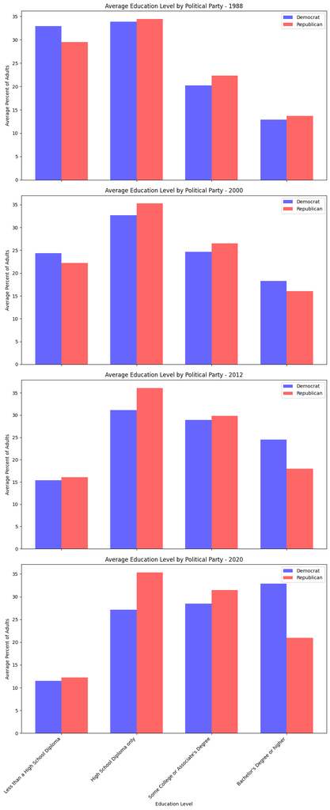

```python
import matplotlib.pyplot as plt

years = election_education_poverty_df['Year'].unique()

education_categories = ['Percent of adults with less than a high school diploma', 'Percent of adults with a high school diploma only',
                        "Percent of adults completing some college or associate's degree", "Percent of adults with a bachelor's degree or higher"]

fig, axes = plt.subplots(len(years), 1, figsize=(10, 6 * len(years)), sharex=True)

for i, year in enumerate(years):
    # Get current year data
    data_year = election_education_poverty_df[election_education_poverty_df['Year'] == year]

    # Calculate average education levels for Democrat and Republican counties
    avg_education_democrat = data_year[data_year['party'] == 'Democrat'][education_categories].mean()
    avg_education_republican = data_year[data_year['party'] == 'Republican'][education_categories].mean()

    # Plot
    index = range(len(education_categories))
    bar_width = 0.35
    axes[i].bar(index, avg_education_democrat, bar_width, label='Democrat', color='blue', alpha=0.6)
    axes[i].bar([x + bar_width for x in index], avg_education_republican, bar_width, label='Republican', color='red', alpha=0.6)

    axes[i].set_title(f'Average Education Level by Political Party - {year}')
    axes[i].set_ylabel('Average Percent of Adults')
    axes[i].set_xticks([x + bar_width / 2 for x in index])
    axes[i].set_xticklabels(['Less than a High School Diploma', 'High School Diploma only', 'Some College or Associate\'s Degree', "Bachelor\'s Degree or higher"], rotation=45, ha='right')
    axes[i].legend()

axes[-1].set_xlabel('Education Level')

plt.tight_layout()
plt.show()
```

**Graph Analysis:** These graphs show the percent of the adult population in each of the four educational attainment categories in each of the four election years. We can see that in the most recent election year, the democratic party is recieving a lot more votes from the "Bacherlor's Degree or higher" category.

Average Poverty Rate by Politcal Party:

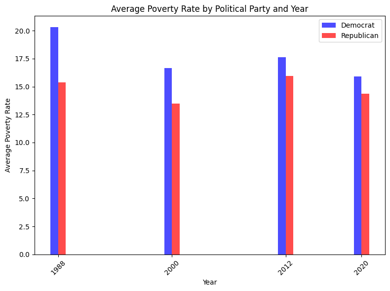

```python
import matplotlib.pyplot as plt

average_poverty_by_year_party = election_education_poverty_df.groupby(['Year', 'party'])['Poverty_rate'].mean().unstack()

plt.figure(figsize=(8, 6))
bar_width = 0.8

# Plot Democrat average poverty rate
plt.bar(average_poverty_by_year_party.index - bar_width/2, average_poverty_by_year_party['Democrat'], color='blue', alpha=0.7, width=bar_width, label='Democrat')

# Plot Republican average poverty rate
plt.bar(average_poverty_by_year_party.index + bar_width/2, average_poverty_by_year_party['Republican'], color='red', alpha=0.7, width=bar_width, label='Republican')

plt.title('Average Poverty Rate by Political Party and Year')
plt.xlabel('Year')
plt.ylabel('Average Poverty Rate')
plt.xticks(average_poverty_by_year_party.index, rotation=45)  # Rotate x-axis labels for better readability
plt.legend()
plt.tight_layout()
plt.show()
```

**Graph Analysis:** Bar charts showing the average poverty rate of the counties that voted republic vs democrat in each of the four election years. This visualizes the mean value of each of these summary statistics. We can see that in each year the average poverty rate is higher in democratic counties vs republican.

Distribution of Poverty Rates by Political Party:

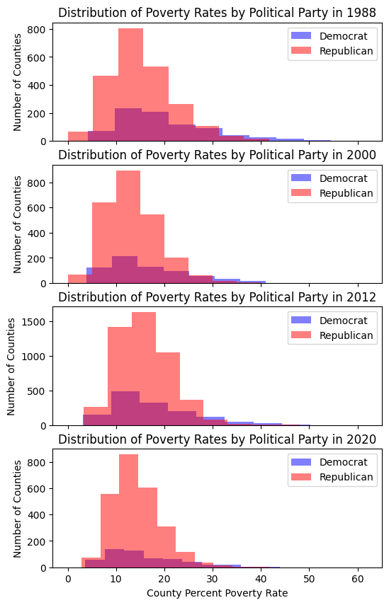

```python
# Plot the distribution of poverty rates by year based on if the county voted democrat or republican

years = election_education_poverty_df['Year'].unique()

fig, axes = plt.subplots(len(years), 1, figsize=(6, 10), sharex=True)

for i, year in enumerate(years):

  axes[i].hist(election_education_poverty_df[(election_education_poverty_df['Year'] == year) & (election_education_poverty_df['party'] == 'Democrat')]['Poverty_rate'],
         alpha=0.5, color='blue', label='Democrat')

  axes[i].hist(election_education_poverty_df[(election_education_poverty_df['Year'] == year) & (election_education_poverty_df['party'] == 'Republican')]['Poverty_rate'],
         alpha=0.5, color='red', label='Republican')
  axes[i].set_title('Distribution of Poverty Rates by Political Party in ' + str(year))
  axes[i].set_ylabel('Number of Counties')
  axes[i].legend()

axes[-1].set_xlabel('County Percent Poverty Rate')
plt.show()
```

**Graph Analysis:** These graphs show the distribution of the county level poverty rates based on if they voted republican or democrat in the four election years. We can see that there isn't a clear difference in the general shape of the distributions, the republican distribution is larger simply because it has more overall counties.

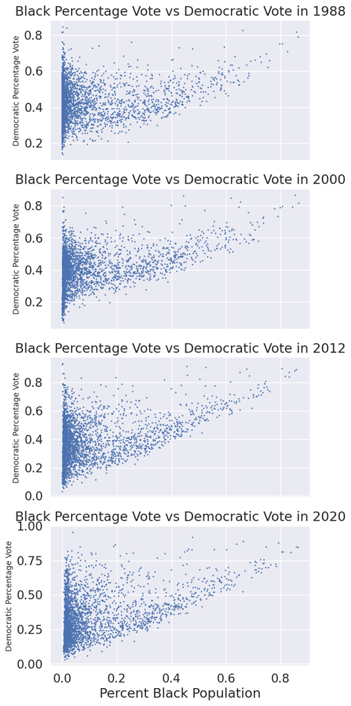

```python
# Create a Scatter Plot of the Black Percentage Population vs Democratic Vote for every year

years = df_demographics['Year'].unique()

fig, axes = plt.subplots(len(years), 1, figsize=(6, 15), sharex=True)

for i, year in enumerate(years):

  # Calculate the black population and the total population in each county

  black_pop = df_demographics[(df_demographics['Year'] == year) & (df_demographics['Race'] == 'Black')].groupby(['FIPS_code'])['Population'].sum()
  total_pop = df_demographics[(df_demographics['Year'] == year)].groupby(['FIPS_code'])['Population'].sum()

  # Merge the population series into a DataFrame and calculate the percent black population

  pop_demographics_df = pd.merge(total_pop.to_frame('Total Population'),
                                black_pop.to_frame('Black Population'),
                                how='left', left_index=True, right_index=True)

  pop_demographics_df['Black Population'].fillna(0, inplace=True)
  pop_demographics_df['Percent Black Population'] = pop_demographics_df['Black Population'] / pop_demographics_df['Total Population']

  # Merge with the election results

  election_categories = ['percent_democrat', "percent_republican"]

  election_pop_demographics_df = pd.merge(pop_demographics_df,
                                          pres_elections_release_df[pres_elections_release_df['election_year'] == year].set_index('fips')[election_categories],
                                          how='left', left_index=True, right_index=True)

  # Create Scatter Plot
  axes[i].scatter(election_pop_demographics_df['Percent Black Population'], election_pop_demographics_df['percent_democrat'], s=.75)
  axes[i].set_ylabel('Democratic Percentage Vote', fontsize=10)
  axes[i].set_title('Black Percentage Vote vs Democratic Vote in ' + str(year))

axes[-1].set_xlabel('Percent Black Population')
plt.show()
```

**Graph Analysis:** These scatter plots show the percent black population plotted against the percent democratic vote in the four election years. We can see from the graphs that in every year as the black population increase, the democratic vote increase, suggesting a strong relationship between these variables.

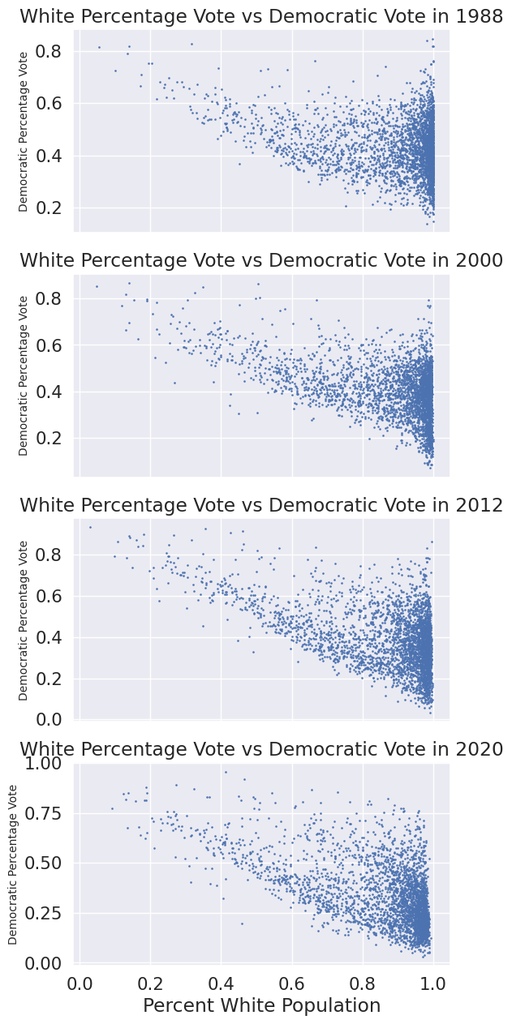

```python
# Create a Scatter Plot of the White Percentage Population vs Democratic Vote for every year

years = df_demographics['Year'].unique()

fig, axes = plt.subplots(len(years), 1, figsize=(6, 15), sharex=True)

for i, year in enumerate(years):

  # Calculate the black population and the total population in each county

  white_pop = df_demographics[(df_demographics['Year'] == year) & (df_demographics['Race'] == 'White')].groupby(['FIPS_code'])['Population'].sum()
  total_pop = df_demographics[(df_demographics['Year'] == year)].groupby(['FIPS_code'])['Population'].sum()

  # Merge the population series into a DataFrame and calculate the percent black population

  pop_demographics_df = pd.merge(total_pop.to_frame('Total Population'),
                                white_pop.to_frame('White Population'),
                                how='left', left_index=True, right_index=True)

  pop_demographics_df['White Population'].fillna(0, inplace=True)
  pop_demographics_df['Percent White Population'] = pop_demographics_df['White Population'] / pop_demographics_df['Total Population']

  # Merge with the election results

  election_categories = ['percent_democrat', "percent_republican"]

  election_pop_demographics_df = pd.merge(pop_demographics_df,
                                          pres_elections_release_df[pres_elections_release_df['election_year'] == year].set_index('fips')[election_categories],
                                          how='left', left_index=True, right_index=True)

  # Create Scatter Plot
  axes[i].scatter(election_pop_demographics_df['Percent White Population'], election_pop_demographics_df['percent_democrat'], s=.75)
  axes[i].set_ylabel('Democratic Percentage Vote', fontsize=10)
  axes[i].set_title('White Percentage Vote vs Democratic Vote in ' + str(year))

axes[-1].set_xlabel('Percent White Population')
plt.show()
```

**Graph Analysis:** We can essentially see the opposite happening here. These scatter plots show the percent white population plotted against the percent democratic vote in the four election years. We can see from the graphs that in every year as the white population increases in the county, the democratic vote decreases, suggesting a strong relationship between these variables.

```python
#more data cleaning
final_demographics_df = pd.DataFrame(columns = ['FIPS_code','Year'])

# calculate percent race for each county in each year

races = df_demographics['Race'].unique()
last_race = ''

for race in races:

  temp_race_df = (df_demographics[(df_demographics['Race'] == race)].groupby(['FIPS_code','Year'])['Population'].sum() /
                  df_demographics.groupby(['FIPS_code','Year'])['Population'].sum()).reset_index()

  final_demographics_df = pd.merge(final_demographics_df, temp_race_df, how='outer', left_on = ['FIPS_code','Year'], right_on=['FIPS_code','Year'], suffixes=(last_race, race))

  last_race = race

# calculate percent origin for each county in each year

origins = df_demographics['Origin'].unique()
last_origin = ''

for origin in origins:

  temp_origin_df = (df_demographics[(df_demographics['Origin'] == origin)].groupby(['FIPS_code','Year'])['Population'].sum() /
                  df_demographics.groupby(['FIPS_code','Year'])['Population'].sum()).reset_index()

  final_demographics_df = pd.merge(final_demographics_df, temp_origin_df, how='outer', left_on = ['FIPS_code','Year'], right_on=['FIPS_code','Year'], suffixes=(last_origin, origin))

  last_origin = origin

# calculate percent sex for each county in each year

sexes = df_demographics['Sex'].unique()
last_sex = ''

for sex in sexes:

  temp_sex_df = (df_demographics[(df_demographics['Sex'] == sex)].groupby(['FIPS_code','Year'])['Population'].sum() /
                  df_demographics.groupby(['FIPS_code','Year'])['Population'].sum()).reset_index()

  final_demographics_df = pd.merge(final_demographics_df, temp_sex_df, how='outer', left_on = ['FIPS_code','Year'], right_on=['FIPS_code','Year'], suffixes=(last_sex, sex))

  last_sex = sex

final_demographics_df
final_demographics_df = final_demographics_df.fillna(0)
```

# **Classification Model**

Model Questions: Classify counties are democrat or republican based on the economic, demographic and educational factors

Features:

- Percentage population based on race
- Percentage population based on sex
- Percentage population based on origin
- Percentage population based on educational attainment
- Poverty rate

Dependent Variable: Presidential Party

```python
# Merge all of the data frames
df = pd.merge(election_education_poverty_df, final_demographics_df, how='inner', on=['FIPS_code', 'Year'])

# drop unnecessary rows
df = df.drop(columns=['county_name', 'democratic_raw_votes', 'republican_raw_votes',
                      'raw_county_vote_totals', 'percent_democrat', 'percent_republican']).copy()

#remove na rows
df = df.dropna()

#remove rows with no party
df = df.drop(df[df['party'] == ''].index).copy()

# Ensure all the percentages are in the form of decimals

divide_columns = ['Percent of adults with less than a high school diploma',
           'Percent of adults with a high school diploma only',
           'Percent of adults completing some college or associate\'s degree',
           'Percent of adults with a bachelor\'s degree or higher', 'Poverty_rate']

df[divide_columns] = df[divide_columns] / 100

df
```

```
Accuracy: 0.84
Confusion Matrix:
[[2355   71]
 [ 439  240]]
```

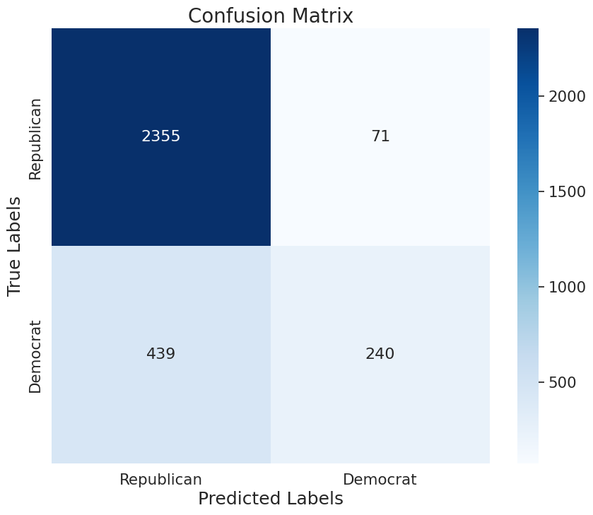

```python
from sklearn.linear_model import LogisticRegression
from sklearn.metrics import accuracy_score, confusion_matrix
from sklearn.model_selection import train_test_split
# from sklearn.metrics import plot_confusion_matrix

features = ['Percent of adults with less than a high school diploma',
            'Percent of adults with a high school diploma only',
            'Percent of adults completing some college or associate\'s degree',
            'Percent of adults with a bachelor\'s degree or higher', 'Poverty_rate', 'PopulationWhite', 'PopulationBlack',
            'PopulationAmerican Indian/Alaska Native',
            'PopulationAsian or Pacific Islander', 'PopulationNon-Hispanic',
            'PopulationHispanic', 'PopulationMale', 'PopulationFemale']

X = df[features]
y = df['party']

# Split data into training and testing sets
X_train, X_test, y_train, y_test = train_test_split(X, y, test_size=0.2, random_state=42, stratify=y)

#train model
model = LogisticRegression(max_iter=1000)
model.fit(X_train, y_train)

#evaluate model
y_pred = model.predict(X_test)
accuracy = accuracy_score(y_test, y_pred)
conf_matrix = confusion_matrix(y_test, y_pred, labels=df['party'].unique())

print(f"Accuracy: {accuracy:.2f}")
print("Confusion Matrix:")
print(conf_matrix)
import seaborn as sns
import matplotlib.pyplot as plt

#plot confusion matrix
plt.figure(figsize=(10, 8))
sns.set(font_scale=1.4)

# Plot using seaborn
sns.heatmap(conf_matrix, annot=True, fmt="d", annot_kws={"size": 16}, cmap='Blues',
            xticklabels=df['party'].unique(), yticklabels=df['party'].unique())  # Font size

plt.xlabel('Predicted Labels', fontsize=18)
plt.ylabel('True Labels', fontsize=18)
plt.title('Confusion Matrix', fontsize=20)
plt.show()
```

```
Accuracy: 0.83
Confusion Matrix:
[[11770   358]
 [ 2223  1174]]
```

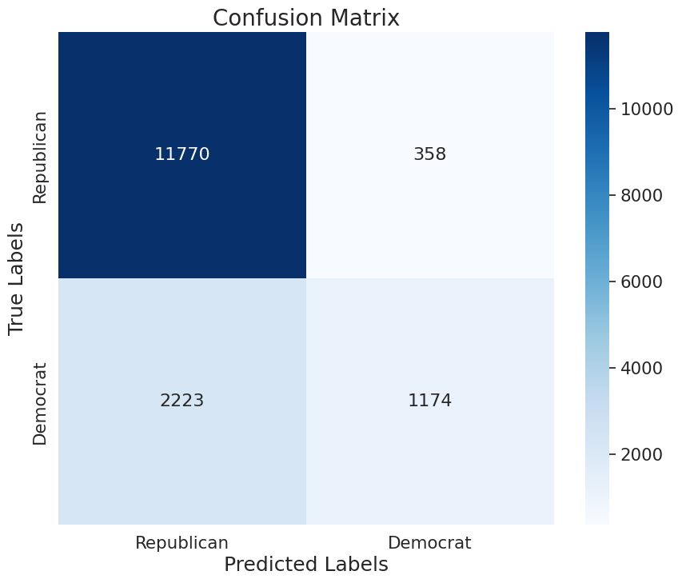

```python
from sklearn.linear_model import LogisticRegression
from sklearn.model_selection import cross_val_predict
from sklearn.metrics import accuracy_score, confusion_matrix
import numpy as np

# Assuming df is your DataFrame
X = df[features]
y = df['party']

# Create a logistic regression model
model = LogisticRegression(max_iter=1000)  # Increase max_iter if convergence issues occur

# Perform cross-validation to get predictions
y_pred = cross_val_predict(model, X, y, cv=5)  # 5-fold cross-validation

# Calculate metrics based on the predictions
accuracy = accuracy_score(y, y_pred)
conf_matrix = confusion_matrix(y, y_pred, labels=df['party'].unique())

# Print the results
print(f"Accuracy: {accuracy:.2f}")
print("Confusion Matrix:")
print(conf_matrix)

#plot confusion matrix
plt.figure(figsize=(10, 8))
sns.set(font_scale=1.4)

# Plot using seaborn
sns.heatmap(conf_matrix, annot=True, fmt="d", annot_kws={"size": 16}, cmap='Blues',
            xticklabels=df['party'].unique(), yticklabels=df['party'].unique())  # Font size

plt.xlabel('Predicted Labels', fontsize=18)
plt.ylabel('True Labels', fontsize=18)
plt.title('Confusion Matrix', fontsize=20)
plt.show()
```

```
1988's Accuracy: 0.76
1988's Confusion Matrix:
[[2235   51]
 [ 698  112]]
```

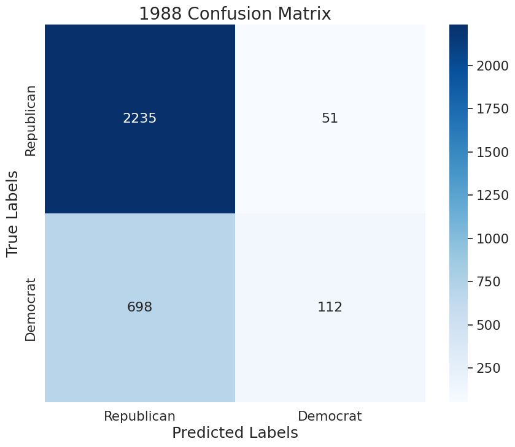

```
2000's Accuracy: 0.83
2000's Confusion Matrix:
[[2381   54]
 [ 489  181]]
```

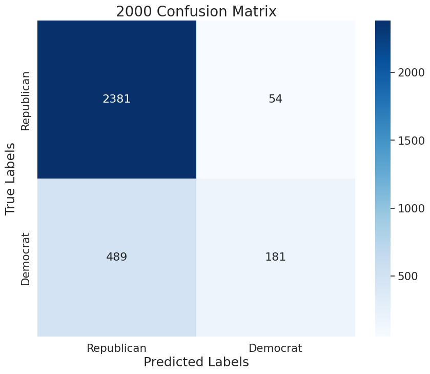

```
2012's Accuracy: 0.85
2012's Confusion Matrix:
[[4654  180]
 [ 746  634]]
```

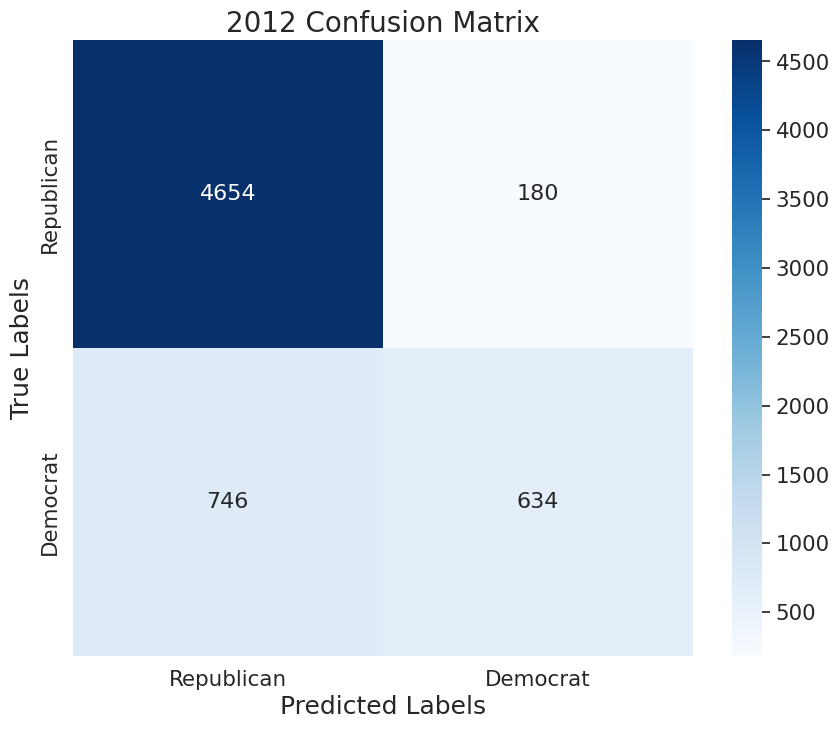

```
2020's Accuracy: 0.91
2020's Confusion Matrix:
[[2514   59]
 [ 232  305]]
```

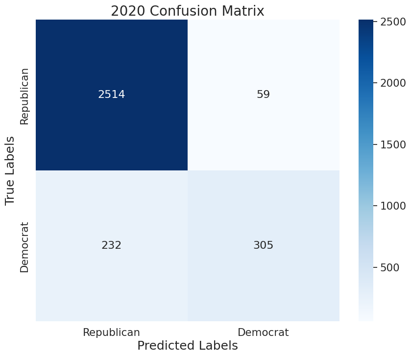

```python
# Create and evaluate a model for each election year

years = df['Year'].unique()

for year in years:
  df_year = df[df['Year'] == year]
  # Assuming df is your DataFrame
  X = df_year[features]
  y = df_year['party']

  # Create a logistic regression model
  model = LogisticRegression(max_iter=1000)  # Increase max_iter if convergence issues occur

  # Perform cross-validation to get predictions
  y_pred = cross_val_predict(model, X, y, cv=5)  # 5-fold cross-validation

  # Calculate metrics based on the predictions
  accuracy = accuracy_score(y, y_pred)
  conf_matrix = confusion_matrix(y, y_pred, labels=df['party'].unique())

  # Print the results
  print(f"{year}'s Accuracy: {accuracy:.2f}")
  print(f"{year}'s Confusion Matrix:")
  print(conf_matrix)

  #plot confusion matrix
  plt.figure(figsize=(10, 8))
  sns.set(font_scale=1.4)

  # Plot using seaborn
  sns.heatmap(conf_matrix, annot=True, fmt="d", annot_kws={"size": 16}, cmap='Blues',
              xticklabels=df['party'].unique(), yticklabels=df['party'].unique())  # Font size

  plt.xlabel('Predicted Labels', fontsize=18)
  plt.ylabel('True Labels', fontsize=18)
  plt.title(f'{year} Confusion Matrix', fontsize=20)
  plt.show()
```

Our model does not perform with as much accuracy as we would have hoped. Although, we noticed that if we restrict it for each respective year, it performs better on certain years. This could be due to the fact that in some years, demographics, poverty level, and education level, had more of a correlation with voting patterns than in other years. This could be due to the candidates and the United States economy and politics of those years.

```python
from google.colab import drive
drive.mount('/content/drive')
```

```python
# !jupyter nbconvert --to html /content/drive/MyDrive/Data_Science_Project/Milestone2.ipynb
```